# Aside

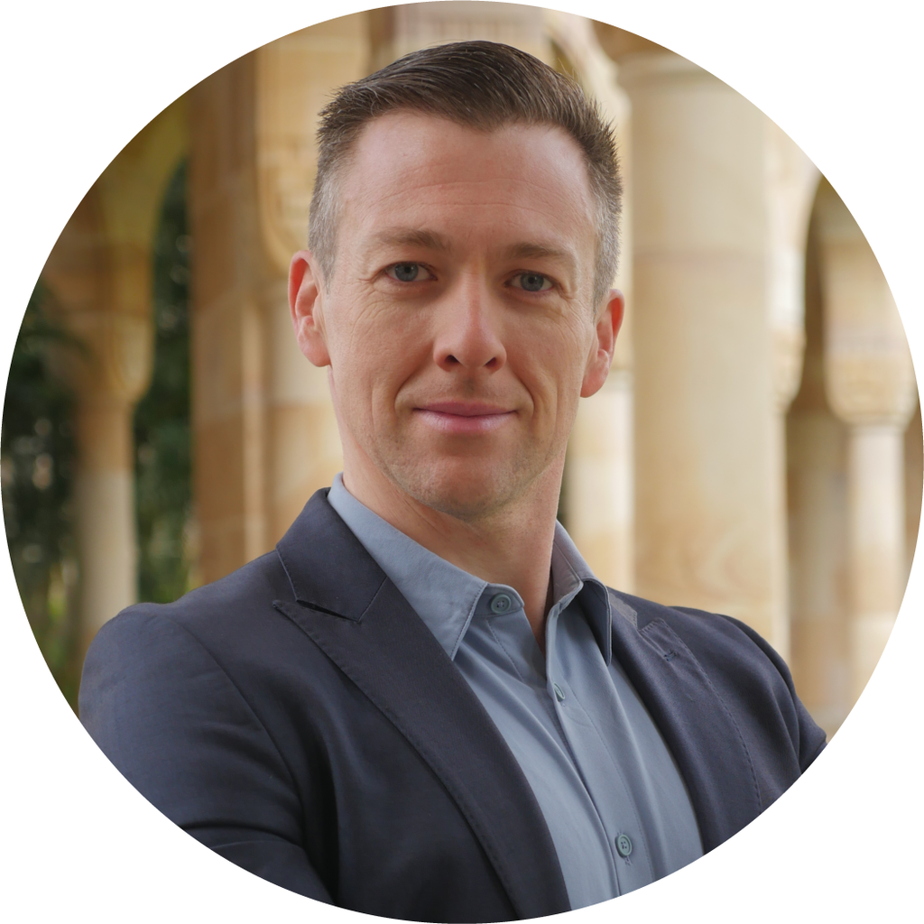

## Contact Info

- m.noetel@uq.edu.au
- +61 414 822 353
- [LinkedIn](https://www.linkedin.com/in/mnoetel/)

## Skills

- **Systematic reviews**, rapid evidence synthesis, and meta‑analyses
- **Expert elicitation** (e.g., Delphi)
- **Agile project leadership** & stakeholder engagement
- **Science communication**: media, policy briefs, knowledge translation
- **Data analysis** & reproducible workflows (R, Git, OSF)

## Academic metrics

h-index: 25  
Publications: 52  
Citations: 2515  
m-index: 3.9  
Last updated: 31 Oct 2025  
via Scopus

# Main

## Michael Noetel, PhD

### **Associate Professor, The University of Queensland**

I work to reduce catastrophic risks from advanced AI while helping others do the most good they can. My work integrates consensus‑building, evidence synthesis, and scalable public communication to deliver policy‑ready guidance at the pace of frontier AI.

### **Select AI Governance Contributions**

- **SARA Project**: Led the Survey of Assessing Risks from AI, which informed Australia’s *Safe and Responsible AI in Australia* discussion paper.
- **AI Risk Repository**: Co‑authored [repository](https://airisk.mit.edu/) of AI risk pathways, cited in the *International AI Safety Report* (2024).
- **Field‑building**: Facilitated three cohorts of the [AGI Safety Fundamentals Governance Course](https://bluedot.org/). Primary or associate supervisor for 9 PhD candidates including students working on frontier AI evaluations, AI consciousness and moral status, AI literacy interventions, and public perception of AI risks.

### **Teaching & Engagement Impact**

- **Award‑winning educator**: 9 national & institutional awards, incl. Australian Award for University Teaching & Vice‑Chancellor’s Award for Excellence. Mean student rating *4.8/5* across 2,390 students.
- **Public science communicator**: 8 *Conversation* articles (210K reads); media interviews for CNN, BBC, ABC, The Times; invited to brief federal parliamentarians.
- **Chair**, Effective Altruism Australia since 2021 — stewarding *AU$5M+/yr* to cost‑effective global‑health and climate programs.

### **Research Excellence**

- **High‑impact evidence synthesis**: Lead author, network meta‑analysis of exercise for depression (*BMJ*, Altmetric > 1400; 100M+ media reach). Publications in *Nature Human Behaviour*, *Psychological Bulletin*, *Review of Educational Research*.
- **Competitive funding**: Chief Investigator on *AU$3.7M* Category 1 grants (NHMRC, MRFF, ARC).
- **Transparent & truth-seeking**: Embed pre-registration, open data/code; lead multi‑institution teams using Agile methods.
- **Metrics of excellence**: m‑index 3.9 (>2 = ‘outstanding scientist’); 53% of papers in top‑10% most‑cited; Field‑Weighted Citation Index = 7.4 (top 1%).

## Education

### **Doctor of Philosophy**

Institute for Positive Psychology and Education  
Australian Catholic University

Sydney, NSW

2019

### **Masters of Applied Psychology**

The University of Queensland

Brisbane, QLD

2010

### **Bachelor of Science (Advanced, Honours)**

Double Major: Psychology; Computational Science  
University of Sydney

Sydney, NSW

2008

## Academic Experience

### **Associate Professor - Teaching and Research**

School of Psychology  
The University of Queensland

Brisbane, QLD

Present - 2025

### **Affiliate Researcher**

FutureTech  
Massachusetts Institute of Technology

Cambridge, MA

Present - 2025

### **Senior Lecturer**

School of Psychology  
The University of Queensland

Brisbane, QLD

2024 - 2022

### **Lecturer to Senior Lecturer**

School of Health and Behavioural Sciences  
Australian Catholic University

Sydney & Brisbane

2022 - 2015

## Research Grants

### AI Risk Index: Assessing influential organizations’ responses to risks from artificial intelligence

Subaward with Massachusetts Institute of Technology

N/A

2026 - 2025

**Noetel, M.**, Saeri, A. — $340,660

### Seeing the Bigger Picture: Exploring Children’s Screen Time and Outcomes through Collaborative Data Analysis

NSW Department of Education

N/A

2026 - 2025

Sanders, T., Conigrave, J., **Noetel, M.**, et al. — $341,307

### Square eyes or all lies? Understanding children’s exposure to screens

Australian Research Council Discovery Project (DP200101912)

N/A

2023 - 2020

Lonsdale, C., Biddle, S., Parker, P., et al., **Noetel, M.** — $658,544

### Protyping a co-designed effective altruism program: Thinking Skills for Global Change

Open Philanthropy

N/A

2023 - 2022

**Noetel, M.** — $58,000

### Meta-review of what works in institutional decision-making

Effective Altruism Infrastructure Fund

N/A

2022 - 2021

**Noetel, M.**, Saeri, A., Slattery, P., Grundy, E. — $39,654

*Chief Investigator on AU$3.7M total competitive funding including NHMRC, MRFF, and ARC grants*

## Selected Publications

### Vasconcellos R.P., et al. (2025). [Electronic Screen Use and Children’s Socioemotional Problems: A Systematic Review and Meta-Analysis of Longitudinal Studies](https://doi.org/10.1037/bul0000451). *Psychological Bulletin* (3 citations)

N/A

N/A

2025

### Noetel M., et al. (2024). [Effect of exercise for depression: Systematic review and network meta-analysis of randomised controlled trials](https://doi.org/10.1136/bmj-2023-075847). *BMJ* (279 citations)

N/A

N/A

2024

### Sanders T., et al. (2024). [An umbrella review of the benefits and risks associated with youths’ interactions with electronic screens](https://doi.org/10.1038/s41562-023-01712-8). *Nature Human Behaviour* (68 citations)

N/A

N/A

2024

### Guo J., et al. (2024). [Harnessing Artificial Intelligence in Generative Content for enhancing motivation in learning](https://doi.org/10.1016/j.lindif.2024.102563). *Learning and Individual Differences* (5 citations)

N/A

N/A

2024

### Ahmadi A., et al. (2023). [A Classification System for Teachers’ Motivational Behaviors Recommended in Self-Determination Theory Interventions](https://doi.org/10.1037/edu0000780). *Journal of Educational Psychology* (238 citations)

N/A

N/A

2023

### Wilhite K., et al. (2023). [Combinations of Physical Activity, Sedentary Behavior, and Sleep Duration and Their Associations With Physical, Psychological, and Educational Outcomes in Children and Adolescents](https://doi.org/10.1093/aje/kwad161). *American Journal of Epidemiology* (96 citations)

N/A

N/A

2023

### Noetel M., et al. (2023). [Prediction Versus Explanation in Educational Psychology](https://doi.org/10.1007/s10648-023-09760-3). *Educational Psychology Review* (13 citations)

N/A

N/A

2023

### Gallardo-Gómez D., et al. (2022). [Optimal dose and type of exercise to improve cognitive function in older adults: A systematic review and bayesian model-based network meta-analysis of RCTs](https://doi.org/10.1016/j.arr.2022.101591). *Ageing Research Reviews* (154 citations)

N/A

N/A

2022

### Noetel M., et al. (2022). [Multimedia Design for Learning: An Overview of Reviews With Meta-Meta-Analysis](https://doi.org/10.3102/00346543211052329). *Review of Educational Research* (83 citations)

N/A

N/A

2022

### Noetel M., et al. (2021). [Video Improves Learning in Higher Education: A Systematic Review](https://doi.org/10.3102/0034654321990713). *Review of Educational Research* (217 citations)

N/A

N/A

2021

### Donald J.N., et al. (2021). [Paths to the Light and Dark Sides of Human Nature](https://doi.org/10.1037/bul0000325). *Psychological Bulletin* (40 citations)

N/A

N/A

2021

### Noetel M., et al. (2019). [Mindfulness and acceptance approaches to sporting performance enhancement: a systematic review](https://doi.org/10.1080/1750984X.2018.1564221). *International Review of Sport and Exercise Psychology* (168 citations)

N/A

N/A

2019

## Accreditations

### **Registered Psychologist**

Australian Health Practitioner Regulation Agency

N/A

Present - 2012

### **Board Approved Supervisor**

Australian Health Practitioner Regulation Agency

N/A

Present - 2015